# INFO370 Data Sprint 1

Author

Swastik Singh, Adam Skoglund, Jah Chen, and Paul Oh

Published

November 12, 2024

**Analysis Summary**

In this analysis, I attempted to address the following question or questions:

To answer these questions, I have done the following sub-tasks:

Example (check options with an x in the brackets)

- Use this tool (0 pts)

Data Wrangling

- Filter or pivot a data frame (0.5 pt)
- Create an appropriate and readable visualization with ggplot2, with interpretable labels and title (0.5 pt)
- Calculate a summary statistic with summarise() (0.5 pt)
- Create a new variable or feature by transforming existing ones (0.5 pt)
- Set the default category or reference level for a factor (0.5 pt)

Model Fitting

- Use simple linear regression with a categorical or numeric predictor (0.5 pt)
- Use multiple linear regression (0.5 pt)
- Use least absolute deviation regression (you still get credit for the two options above if you do this; it’s an add-on) (0.5 pt)

Predictions

- Manually calculate a prediction for some novel individual using a linear model (0.5 pt)
- Automatically create predictions for multiple data points using a linear model (0.5 pt)
- Visualize residuals from predictions from a linear model (0.5 pt)
- Quantify the performance of one or more linear models by calculating mean squared error or mean absolute deviation with residuals (1 pts)

Confidence Intervals

- Calculate a 95% confidence interval using bootstrapping for a proportion, mean, median, mode, or other summary statistic that describes a single variable (0.5 pt)
- Calculate a 95% confidence interval using bootstrapping for some statistic that *relates* two or more difference variables to each other (0.5 pt)
- Calculate a 95% confidence interval using bootstrapping that involves a proportion or risk ratio (you still get credit for the two options above if you do this; it’s an add-on) (0.5 pt)
- Calculate the 95% confidence intervals for the parameters of a linear model (0.5 pt)

Justifications (these should be included just before using a summary statistic or fitting a model; bold the text for these using double asterisks.)

- Draw a DAG that includes at least 4 variables (1 pts)
- Write 2-3 sentences that identifies at least 3 variables as colliders, mediators, or confounders for some causal analysis (0.5 pt)
- Write a 1-3 sentence justification for the choice of a summary statistic that you use (0.5 pt)
- Write a 1-3 sentence justification for the choice to use least squares or least absolute deviation when fitting a linear model (0.5 pt)

My analysis used enough sub-tasks to be worth 6 points.

# My Analysis

## Question

How can we predict the number of scans ordered for each provider based on if they are using the CDS system, years since provider graduation, and if the provider is primarily an emergency provider.

## Set up environment and Data Wrangling

### Load libraries

```r
library(tidyverse)
library(infer)
```

### Load data

```r
load("C:/Users/Fortu/Downloads/Aut2024/Info 370/INFO370_DataSprint1/INFO370_DataSprint1/cds_data.RData")
# glimpse(provider_full)
```

```r
# provider_full: the dataset we will be using
provider <- provider_full |>
  select(treated,
         scan_bpa_new,
         scan_bpa_new_q,
         provider_graduation_q,
         most_enc_ed_q,
         Iquit_sp,
         Iquit_qp)

provider |>
  glimpse()
```

```
Rows: 3,511
Columns: 7
$ treated               <dbl> 0, 1, 0, 0, 0, 0, 0, 1, 1, 0, 1, 0, 0, 0, 1, 0, …
$ scan_bpa_new          <dbl> 23, 0, 10, 0, 79, 20, 0, 0, 9, 27, 1, 0, 0, 0, 0…
$ scan_bpa_new_q        <dbl> 17, 0, 2, 0, 16, 8, 0, 0, 11, 3, 1, 0, 0, 0, 0, …
$ provider_graduation_q <dbl> 25, 28, -9999, 33, 3, 31, 41, 36, 31, 42, 41, 36…
$ most_enc_ed_q         <dbl> 0, 1, 1, 0, 1, 0, 0, 0, 0, 0, 0, 0, 0, 0, 1, 0, …
$ Iquit_sp              <dbl> 0, 0, 0, 1, 0, 0, 1, 0, 0, 0, 0, 0, 0, 1, 0, 0, …
$ Iquit_qp              <dbl> 0, 0, 0, 0, 0, 0, 0, 0, 0, 0, 0, 0, 0, 0, 0, 0, …
```

```r
str(provider)
```

```
tibble [3,511 × 7] (S3: tbl_df/tbl/data.frame)
 $ treated              : num [1:3511] 0 1 0 0 0 0 0 1 1 0 ...
  ..- attr(*, "label")= chr "Provider is in treated group"
  ..- attr(*, "format.stata")= chr "%9.0g"
 $ scan_bpa_new         : num [1:3511] 23 0 10 0 79 20 0 0 9 27 ...
  ..- attr(*, "label")= chr "Number targeted scans"
  ..- attr(*, "format.stata")= chr "%9.0g"
 $ scan_bpa_new_q       : num [1:3511] 17 0 2 0 16 8 0 0 11 3 ...
  ..- attr(*, "label")= chr "QP number targeted scans"
  ..- attr(*, "format.stata")= chr "%9.0g"
 $ provider_graduation_q: num [1:3511] 25 28 -9999 33 3 ...
  ..- attr(*, "label")= chr "Years since provider graduation"
  ..- attr(*, "format.stata")= chr "%9.0g"
 $ most_enc_ed_q        : num [1:3511] 0 1 1 0 1 0 0 0 0 0 ...
  ..- attr(*, "label")= chr "Provider had most QP encounters in the ED"
  ..- attr(*, "format.stata")= chr "%9.0g"
 $ Iquit_sp             : num [1:3511] 0 0 0 1 0 0 1 0 0 0 ...
  ..- attr(*, "label")= chr "Provider left health system in the study period"
  ..- attr(*, "format.stata")= chr "%9.0g"
 $ Iquit_qp             : num [1:3511] 0 0 0 0 0 0 0 0 0 0 ...
  ..- attr(*, "label")= chr "Provider left health system in the quiet period"
  ..- attr(*, "format.stata")= chr "%9.0g"
```

```r
provider <- provider |>
  mutate(treated = factor(treated),
         most_enc_ed_q = factor(most_enc_ed_q),
         Iquit_sp = factor(Iquit_sp),
         Iquit_qp = factor(Iquit_qp))

provider |>
  glimpse()
```

```
Rows: 3,511
Columns: 7
$ treated               <fct> 0, 1, 0, 0, 0, 0, 0, 1, 1, 0, 1, 0, 0, 0, 1, 0, …
$ scan_bpa_new          <dbl> 23, 0, 10, 0, 79, 20, 0, 0, 9, 27, 1, 0, 0, 0, 0…
$ scan_bpa_new_q        <dbl> 17, 0, 2, 0, 16, 8, 0, 0, 11, 3, 1, 0, 0, 0, 0, …
$ provider_graduation_q <dbl> 25, 28, -9999, 33, 3, 31, 41, 36, 31, 42, 41, 36…
$ most_enc_ed_q         <fct> 0, 1, 1, 0, 1, 0, 0, 0, 0, 0, 0, 0, 0, 0, 1, 0, …
$ Iquit_sp              <fct> 0, 0, 0, 1, 0, 0, 1, 0, 0, 0, 0, 0, 0, 1, 0, 0, …
$ Iquit_qp              <fct> 0, 0, 0, 0, 0, 0, 0, 0, 0, 0, 0, 0, 0, 0, 0, 0, …
```

```r
provider <- provider |>
  filter(Iquit_qp == 0) %>%
  filter(Iquit_sp == 0)

provider |>
  group_by(Iquit_qp) |>
  tally()
```

```
# A tibble: 1 × 2
  Iquit_qp     n
  <fct>    <int>
1 0         3109
```

```r
provider <- provider |>
  mutate(provider_graduation_q = na_if(provider_graduation_q, -9999))
```

```r
provider <- provider |>
  mutate(change_in_scans = scan_bpa_new - (scan_bpa_new_q  / 8) * 12)
```

### Summary Statistics

```r
provider |>
  summary()
```

```
 treated   scan_bpa_new    scan_bpa_new_q   provider_graduation_q most_enc_ed_q
 0:1548   Min.   :  0.00   Min.   :  0.00   Min.   : 0.00         0:2556
 1:1561   1st Qu.:  0.00   1st Qu.:  0.00   1st Qu.:14.00         1: 553
          Median :  5.00   Median :  3.00   Median :22.00
          Mean   : 17.89   Mean   : 11.86   Mean   :22.21
          3rd Qu.: 20.00   3rd Qu.: 13.00   3rd Qu.:30.00
          Max.   :331.00   Max.   :245.00   Max.   :58.00
                                            NA's   :923
 Iquit_sp Iquit_qp change_in_scans
 0:3109   0:3109   Min.   :-175.5000
 1:   0   1:   0   1st Qu.:  -2.5000
                   Median :   0.0000
                   Mean   :   0.1045
                   3rd Qu.:   2.5000
                   Max.   : 280.0000
```

### Visualizations

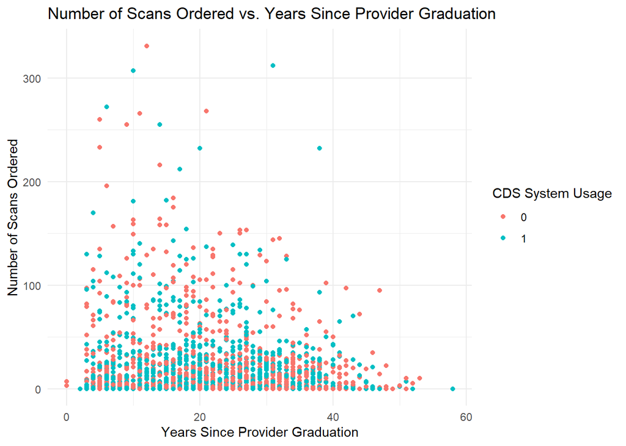

```r
# Visualization: Number of scans ordered vs. years since provider graduation, colored by CDS system usage
ggplot(provider, aes(x = provider_graduation_q, y = scan_bpa_new, color = treated)) +
   geom_point() +
   labs(
      title = "Number of Scans Ordered vs. Years Since Provider Graduation",
      x = "Years Since Provider Graduation",
      y = "Number of Scans Ordered",
      color = "CDS System Usage"
   ) +
   theme_minimal()
```

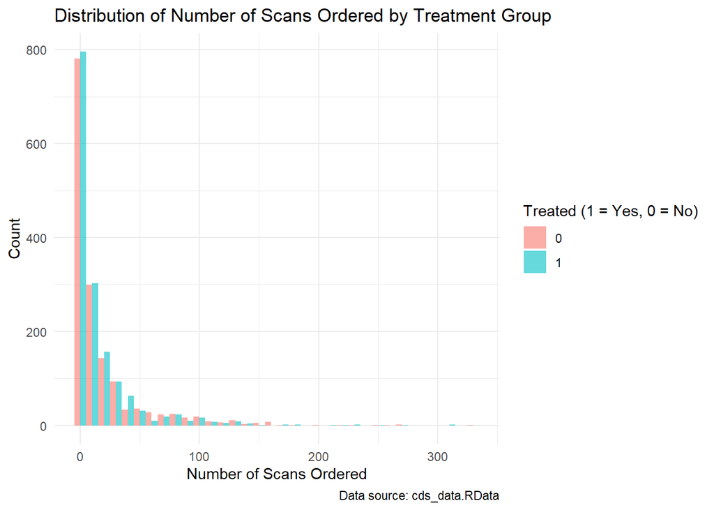

```r
ggplot(provider, aes(x = scan_bpa_new, fill = factor(treated))) +
  geom_histogram(binwidth = 10, alpha = 0.6, position = "dodge") +
  labs(
    title = "Distribution of Number of Scans Ordered by Treatment Group",
    x = "Number of Scans Ordered",
    y = "Count",
    fill = "Treated (1 = Yes, 0 = No)",
    caption = "Data source: cds_data.RData"
  ) +
  theme_minimal()
```

## Model Fitting

### Simple Linear Regression

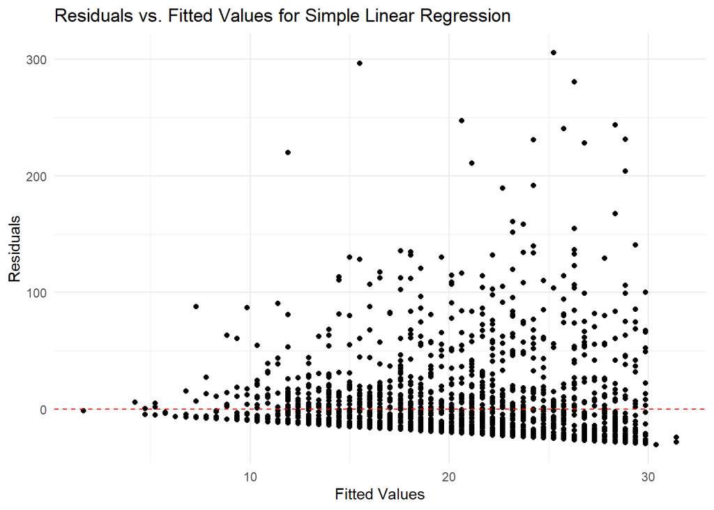

```r
simple_lm <- lm(scan_bpa_new ~ provider_graduation_q, data = provider)
# Visualization: Residuals vs. Fitted values for Simple Linear Regression
ggplot(simple_lm, aes(.fitted, .resid)) +
   geom_point() +
   geom_hline(yintercept = 0, linetype = "dashed", color = "red") +
   labs(
      title = "Residuals vs. Fitted Values for Simple Linear Regression",
      x = "Fitted Values",
      y = "Residuals"
   ) +
   theme_minimal()
```

```r
summary(simple_lm)
```

```
Call:
lm(formula = scan_bpa_new ~ provider_graduation_q, data = provider)

Residuals:
   Min     1Q Median     3Q    Max
-30.39 -18.85 -11.98   4.22 305.75

Coefficients:
                      Estimate Std. Error t value Pr(>|t|)
(Intercept)           31.41281    1.76071  17.841  < 2e-16 ***
provider_graduation_q -0.51339    0.07152  -7.178 9.63e-13 ***
---
Signif. codes:  0 '***' 0.001 '**' 0.01 '*' 0.05 '.' 0.1 ' ' 1

Residual standard error: 35.55 on 2184 degrees of freedom
  (923 observations deleted due to missingness)
Multiple R-squared:  0.02305,   Adjusted R-squared:  0.0226
F-statistic: 51.53 on 1 and 2184 DF,  p-value: 9.627e-13
```

### Multiple Linear Regression

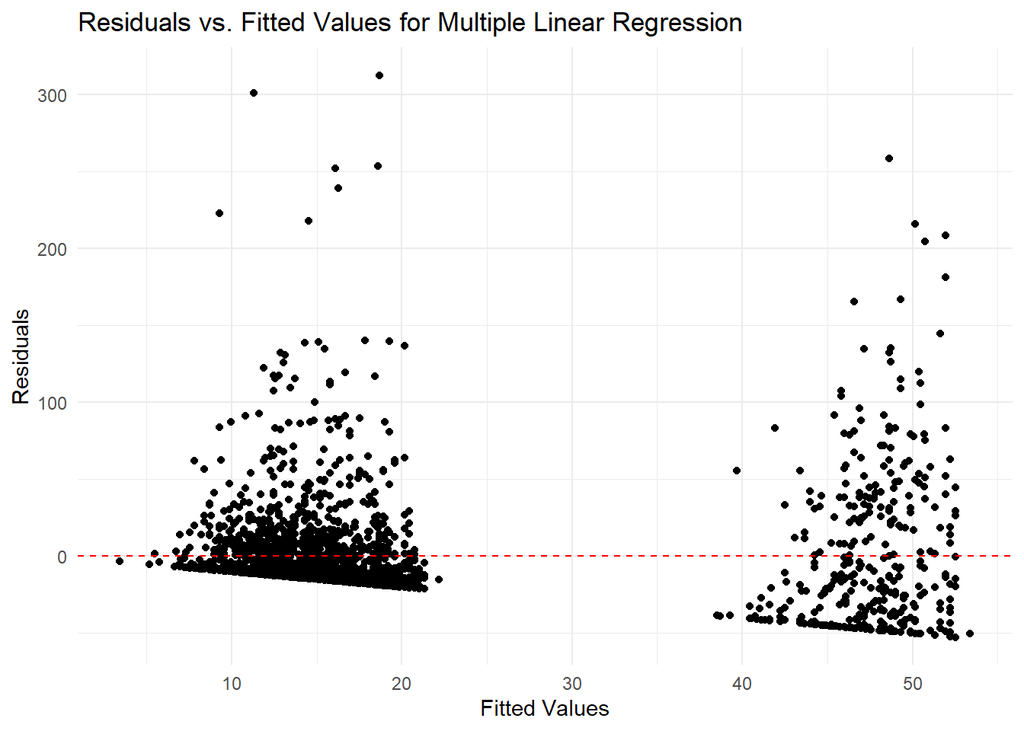

```r
multiple_lm <- lm(scan_bpa_new ~ treated + provider_graduation_q + most_enc_ed_q, data = provider)
# Visualization: Residuals vs. Fitted values for Multiple Linear Regression
ggplot(multiple_lm, aes(.fitted, .resid)) +
   geom_point() +
   geom_hline(yintercept = 0, linetype = "dashed", color = "red") +
   labs(
      title = "Residuals vs. Fitted Values for Multiple Linear Regression",
      x = "Fitted Values",
      y = "Residuals"
   ) +
   theme_minimal()
```

```r
summary(multiple_lm)
```

```
Call:
lm(formula = scan_bpa_new ~ treated + provider_graduation_q +
    most_enc_ed_q, data = provider)

Residuals:
    Min      1Q  Median      3Q     Max
-52.506 -14.904  -9.654   5.661 312.304

Coefficients:
                      Estimate Std. Error t value Pr(>|t|)
(Intercept)           22.19652    1.93376  11.478  < 2e-16 ***
treated1              -1.83657    1.44027  -1.275    0.202
provider_graduation_q -0.29170    0.06917  -4.217 2.58e-05 ***
most_enc_ed_q1        31.18445    1.96956  15.833  < 2e-16 ***
---
Signif. codes:  0 '***' 0.001 '**' 0.01 '*' 0.05 '.' 0.1 ' ' 1

Residual standard error: 33.67 on 2182 degrees of freedom
  (923 observations deleted due to missingness)
Multiple R-squared:  0.1245,    Adjusted R-squared:  0.1233
F-statistic: 103.4 on 3 and 2182 DF,  p-value: < 2.2e-16
```

```r
dummy_providers <- data.frame(treated = c(0, 0, 1, 0, 1, 1, 1, 0),
                              provider_graduation_q = c(25, 3, 9, 10, 50, 30, 16, 32),
                              most_enc_ed_q = c(1, 0, 1, 0, 0, 1, 0, 1))

dummy_providers <- dummy_providers |>
  mutate(treated = factor(treated),
         most_enc_ed_q = factor(most_enc_ed_q))

dummy_providers$change_in_scans <- predict(multiple_lm, dummy_providers)

dummy_providers |>
  glimpse()
```

```
Rows: 8
Columns: 4
$ treated               <fct> 0, 0, 1, 0, 1, 1, 1, 0
$ provider_graduation_q <dbl> 25, 3, 9, 10, 50, 30, 16, 32
$ most_enc_ed_q         <fct> 1, 0, 1, 0, 0, 1, 0, 1
$ change_in_scans       <dbl> 46.088413, 21.321410, 48.919076, 19.279494, 5.77…
```

## Confidence Intervals

### Calculate a 95% confidence interval using bootstrapping for a proportion, mean, median, mode, or other summary statistic that describes a single variable

```r
scans_data <- provider |>
  specify(response = change_in_scans) |>
  generate(reps = 1000, type = "bootstrap") |>
  calculate(stat = "mean") |>
  get_confidence_interval(type = "percentile", level = 0.95)
scans_data
```

```
# A tibble: 1 × 2
  lower_ci upper_ci
     <dbl>    <dbl>
1   -0.425    0.647
```

## Justifications

### DAG

[output not shown]

# Conceptual Questions

For the following section, fill in text for your answers. Do not alter the overall structure of the document!

## Conceptual Question 1: Types of Analysis

For each of the following types of analysis, write about one sentence that defines that type of analysis relative to the other types and write one to three sentences that describe an example of how the current data set could be used for each type of analysis (what is a question you could ask/answer using the data set?). *Don’t use the original question the data set was intended to answer, but you can include questions from your current analysis.*.

- Causal Analysis
  - Definition: Causal analysis aims to determine whether one variable directly affects another variable.
  - Example: Using the current data set, we could investigate whether the use of the CDS system causes a reduction in the number of scans ordered by providers.
- Descriptive Analysis
  - Definition: Descriptive analysis focuses on summarizing and describing the main features of a data set.
  - Example: We could use the data set to describe the distribution of the number of scans ordered by providers, including measures such as mean, median, and standard deviation.
- Predictive Analysis
  - Definition: Predictive analysis uses historical data to make predictions about future events or outcomes.
  - Example: We could use the data set to predict the number of scans a provider is likely to order based on their years since graduation and whether they use the CDS system.

## Conceptual Question 2: Validity

For each of the types of validity below, write a definition in your own words (about 1 sentence). Then, for your analysis of the current data set, write an example of something you would want to check or consider to ensure your analysis is (at least decently) valid. If the type of validity is irrelevant, then say so and say why. Write 2-3 sentences for each example.

- Construct Validity
  - Definition: Construct validity refers to how well a test or tool measures the concept that it is intended to measure.
  - Example: To ensure construct validity in our analysis, we need to verify that the variables we use (e.g., CDS system usage, years since provider graduation) accurately represent the constructs we are interested in (e.g., technology adoption, experience level).
- External Validity
  - Definition: External validity is the extent to which the results of a study can be generalized to other settings, populations, and times.
  - Example: To ensure external validity, we should consider whether the sample of providers in our data set is representative of the broader population of providers. If our sample is biased or not diverse, our findings may not be generalizable.
- Internal Validity
  - Definition: Internal validity refers to the extent to which a study can establish a cause-and-effect relationship between variables, free from confounding factors.
  - Example: To ensure internal validity, we need to control for potential confounders that could affect the relationship between CDS system usage and the number of scans ordered. This might involve including additional variables in our regression model or using techniques like matching or randomization.

# That’s all!

Make sure you check all the boxes and put in conclusions at the top of the document, render your report and submit it!